# Risk Factor Analysis

## Outcome Variable

**Outcome Variable:** wast_rec90d

## Predictor Variables

**Intervention Variable:** mage

**Adjustment Set:**

unadjusted

## Stratifying Variables

The analysis was stratified on these variable(s):

- agecat
- studyid
- country

## Data Summary

| agecat | studyid | country | mage | wast_rec90d | n_cell | n |
| --- | --- | --- | --- | --- | --- | --- |
| 0-24 months | CMC-V-BCS-2002 | INDIA | [20-30) | 0 | 98 | 324 |
| 0-24 months | CMC-V-BCS-2002 | INDIA | [20-30) | 1 | 153 | 324 |
| 0-24 months | CMC-V-BCS-2002 | INDIA | <20 | 0 | 8 | 324 |
| 0-24 months | CMC-V-BCS-2002 | INDIA | <20 | 1 | 27 | 324 |
| 0-24 months | CMC-V-BCS-2002 | INDIA | >=30 | 0 | 14 | 324 |
| 0-24 months | CMC-V-BCS-2002 | INDIA | >=30 | 1 | 24 | 324 |
| 0-24 months | COHORTS | GUATEMALA | [20-30) | 0 | 104 | 380 |
| 0-24 months | COHORTS | GUATEMALA | [20-30) | 1 | 79 | 380 |
| 0-24 months | COHORTS | GUATEMALA | <20 | 0 | 24 | 380 |
| 0-24 months | COHORTS | GUATEMALA | <20 | 1 | 28 | 380 |
| 0-24 months | COHORTS | GUATEMALA | >=30 | 0 | 84 | 380 |
| 0-24 months | COHORTS | GUATEMALA | >=30 | 1 | 61 | 380 |
| 0-24 months | COHORTS | INDIA | [20-30) | 0 | 936 | 1940 |
| 0-24 months | COHORTS | INDIA | [20-30) | 1 | 302 | 1940 |
| 0-24 months | COHORTS | INDIA | <20 | 0 | 136 | 1940 |
| 0-24 months | COHORTS | INDIA | <20 | 1 | 34 | 1940 |
| 0-24 months | COHORTS | INDIA | >=30 | 0 | 411 | 1940 |
| 0-24 months | COHORTS | INDIA | >=30 | 1 | 121 | 1940 |
| 0-24 months | COHORTS | PHILIPPINES | [20-30) | 0 | 379 | 1689 |
| 0-24 months | COHORTS | PHILIPPINES | [20-30) | 1 | 575 | 1689 |
| 0-24 months | COHORTS | PHILIPPINES | <20 | 0 | 98 | 1689 |
| 0-24 months | COHORTS | PHILIPPINES | <20 | 1 | 152 | 1689 |
| 0-24 months | COHORTS | PHILIPPINES | >=30 | 0 | 187 | 1689 |
| 0-24 months | COHORTS | PHILIPPINES | >=30 | 1 | 298 | 1689 |
| 0-24 months | EE | PAKISTAN | [20-30) | 0 | 63 | 320 |
| 0-24 months | EE | PAKISTAN | [20-30) | 1 | 61 | 320 |
| 0-24 months | EE | PAKISTAN | <20 | 0 | 0 | 320 |
| 0-24 months | EE | PAKISTAN | <20 | 1 | 1 | 320 |
| 0-24 months | EE | PAKISTAN | >=30 | 0 | 95 | 320 |
| 0-24 months | EE | PAKISTAN | >=30 | 1 | 100 | 320 |

[output cut: 432 more lines]

The following strata were considered:

- agecat: 0-24 months, studyid: CMC-V-BCS-2002, country: INDIA
- agecat: 0-24 months, studyid: COHORTS, country: GUATEMALA
- agecat: 0-24 months, studyid: COHORTS, country: INDIA
- agecat: 0-24 months, studyid: COHORTS, country: PHILIPPINES
- agecat: 0-24 months, studyid: EE, country: PAKISTAN
- agecat: 0-24 months, studyid: GMS-Nepal, country: NEPAL
- agecat: 0-24 months, studyid: Guatemala BSC, country: GUATEMALA
- agecat: 0-24 months, studyid: iLiNS-Zinc, country: BURKINA FASO
- agecat: 0-24 months, studyid: IRC, country: INDIA
- agecat: 0-24 months, studyid: Keneba, country: GAMBIA
- agecat: 0-24 months, studyid: LCNI-5, country: MALAWI
- agecat: 0-24 months, studyid: MAL-ED, country: BANGLADESH
- agecat: 0-24 months, studyid: MAL-ED, country: BRAZIL
- agecat: 0-24 months, studyid: MAL-ED, country: INDIA
- agecat: 0-24 months, studyid: MAL-ED, country: NEPAL
- agecat: 0-24 months, studyid: MAL-ED, country: PERU
- agecat: 0-24 months, studyid: MAL-ED, country: SOUTH AFRICA
- agecat: 0-24 months, studyid: MAL-ED, country: TANZANIA, UNITED REPUBLIC OF
- agecat: 0-24 months, studyid: NIH-Birth, country: BANGLADESH
- agecat: 0-24 months, studyid: NIH-Crypto, country: BANGLADESH
- agecat: 0-24 months, studyid: PROBIT, country: BELARUS
- agecat: 0-24 months, studyid: PROVIDE, country: BANGLADESH
- agecat: 0-24 months, studyid: SAS-CompFeed, country: INDIA
- agecat: 0-24 months, studyid: SAS-FoodSuppl, country: INDIA
- agecat: 0-24 months, studyid: TanzaniaChild2, country: TANZANIA, UNITED REPUBLIC OF
- agecat: 0-24 months, studyid: ZVITAMBO, country: ZIMBABWE
- agecat: 0-6 months, studyid: CMC-V-BCS-2002, country: INDIA
- agecat: 0-6 months, studyid: COHORTS, country: GUATEMALA
- agecat: 0-6 months, studyid: COHORTS, country: INDIA
- agecat: 0-6 months, studyid: COHORTS, country: PHILIPPINES
- agecat: 0-6 months, studyid: EE, country: PAKISTAN
- agecat: 0-6 months, studyid: GMS-Nepal, country: NEPAL
- agecat: 0-6 months, studyid: Guatemala BSC, country: GUATEMALA
- agecat: 0-6 months, studyid: IRC, country: INDIA
- agecat: 0-6 months, studyid: Keneba, country: GAMBIA
- agecat: 0-6 months, studyid: LCNI-5, country: MALAWI
- agecat: 0-6 months, studyid: MAL-ED, country: BANGLADESH
- agecat: 0-6 months, studyid: MAL-ED, country: BRAZIL
- agecat: 0-6 months, studyid: MAL-ED, country: INDIA
- agecat: 0-6 months, studyid: MAL-ED, country: NEPAL
- agecat: 0-6 months, studyid: MAL-ED, country: PERU
- agecat: 0-6 months, studyid: MAL-ED, country: SOUTH AFRICA
- agecat: 0-6 months, studyid: MAL-ED, country: TANZANIA, UNITED REPUBLIC OF
- agecat: 0-6 months, studyid: NIH-Birth, country: BANGLADESH
- agecat: 0-6 months, studyid: NIH-Crypto, country: BANGLADESH
- agecat: 0-6 months, studyid: PROBIT, country: BELARUS
- agecat: 0-6 months, studyid: PROVIDE, country: BANGLADESH
- agecat: 0-6 months, studyid: SAS-CompFeed, country: INDIA
- agecat: 0-6 months, studyid: SAS-FoodSuppl, country: INDIA
- agecat: 0-6 months, studyid: TanzaniaChild2, country: TANZANIA, UNITED REPUBLIC OF
- agecat: 0-6 months, studyid: ZVITAMBO, country: ZIMBABWE
- agecat: 6-24 months, studyid: CMC-V-BCS-2002, country: INDIA
- agecat: 6-24 months, studyid: COHORTS, country: GUATEMALA
- agecat: 6-24 months, studyid: COHORTS, country: INDIA
- agecat: 6-24 months, studyid: COHORTS, country: PHILIPPINES
- agecat: 6-24 months, studyid: EE, country: PAKISTAN
- agecat: 6-24 months, studyid: GMS-Nepal, country: NEPAL
- agecat: 6-24 months, studyid: Guatemala BSC, country: GUATEMALA
- agecat: 6-24 months, studyid: iLiNS-Zinc, country: BURKINA FASO
- agecat: 6-24 months, studyid: IRC, country: INDIA
- agecat: 6-24 months, studyid: Keneba, country: GAMBIA
- agecat: 6-24 months, studyid: LCNI-5, country: MALAWI
- agecat: 6-24 months, studyid: MAL-ED, country: BANGLADESH
- agecat: 6-24 months, studyid: MAL-ED, country: BRAZIL
- agecat: 6-24 months, studyid: MAL-ED, country: INDIA
- agecat: 6-24 months, studyid: MAL-ED, country: NEPAL
- agecat: 6-24 months, studyid: MAL-ED, country: PERU
- agecat: 6-24 months, studyid: MAL-ED, country: SOUTH AFRICA
- agecat: 6-24 months, studyid: MAL-ED, country: TANZANIA, UNITED REPUBLIC OF
- agecat: 6-24 months, studyid: NIH-Birth, country: BANGLADESH
- agecat: 6-24 months, studyid: NIH-Crypto, country: BANGLADESH
- agecat: 6-24 months, studyid: PROBIT, country: BELARUS
- agecat: 6-24 months, studyid: PROVIDE, country: BANGLADESH
- agecat: 6-24 months, studyid: SAS-CompFeed, country: INDIA
- agecat: 6-24 months, studyid: SAS-FoodSuppl, country: INDIA
- agecat: 6-24 months, studyid: TanzaniaChild2, country: TANZANIA, UNITED REPUBLIC OF
- agecat: 6-24 months, studyid: ZVITAMBO, country: ZIMBABWE

### Dropped Strata

Some strata were dropped due to rare outcomes:

- agecat: 0-24 months, studyid: EE, country: PAKISTAN
- agecat: 0-24 months, studyid: Guatemala BSC, country: GUATEMALA
- agecat: 0-24 months, studyid: iLiNS-Zinc, country: BURKINA FASO
- agecat: 0-24 months, studyid: LCNI-5, country: MALAWI
- agecat: 0-24 months, studyid: MAL-ED, country: BRAZIL
- agecat: 0-24 months, studyid: MAL-ED, country: INDIA
- agecat: 0-24 months, studyid: MAL-ED, country: NEPAL
- agecat: 0-24 months, studyid: MAL-ED, country: PERU
- agecat: 0-24 months, studyid: MAL-ED, country: SOUTH AFRICA
- agecat: 0-24 months, studyid: MAL-ED, country: TANZANIA, UNITED REPUBLIC OF
- agecat: 0-24 months, studyid: SAS-FoodSuppl, country: INDIA
- agecat: 0-6 months, studyid: CMC-V-BCS-2002, country: INDIA
- agecat: 0-6 months, studyid: EE, country: PAKISTAN
- agecat: 0-6 months, studyid: Guatemala BSC, country: GUATEMALA
- agecat: 0-6 months, studyid: LCNI-5, country: MALAWI
- agecat: 0-6 months, studyid: MAL-ED, country: BANGLADESH
- agecat: 0-6 months, studyid: MAL-ED, country: BRAZIL
- agecat: 0-6 months, studyid: MAL-ED, country: INDIA
- agecat: 0-6 months, studyid: MAL-ED, country: NEPAL
- agecat: 0-6 months, studyid: MAL-ED, country: PERU
- agecat: 0-6 months, studyid: MAL-ED, country: SOUTH AFRICA
- agecat: 0-6 months, studyid: MAL-ED, country: TANZANIA, UNITED REPUBLIC OF
- agecat: 0-6 months, studyid: NIH-Crypto, country: BANGLADESH
- agecat: 0-6 months, studyid: PROVIDE, country: BANGLADESH
- agecat: 0-6 months, studyid: SAS-FoodSuppl, country: INDIA
- agecat: 6-24 months, studyid: CMC-V-BCS-2002, country: INDIA
- agecat: 6-24 months, studyid: COHORTS, country: GUATEMALA
- agecat: 6-24 months, studyid: COHORTS, country: INDIA
- agecat: 6-24 months, studyid: EE, country: PAKISTAN
- agecat: 6-24 months, studyid: Guatemala BSC, country: GUATEMALA
- agecat: 6-24 months, studyid: iLiNS-Zinc, country: BURKINA FASO
- agecat: 6-24 months, studyid: IRC, country: INDIA
- agecat: 6-24 months, studyid: LCNI-5, country: MALAWI
- agecat: 6-24 months, studyid: MAL-ED, country: BRAZIL
- agecat: 6-24 months, studyid: MAL-ED, country: INDIA
- agecat: 6-24 months, studyid: MAL-ED, country: NEPAL
- agecat: 6-24 months, studyid: MAL-ED, country: PERU
- agecat: 6-24 months, studyid: MAL-ED, country: SOUTH AFRICA
- agecat: 6-24 months, studyid: MAL-ED, country: TANZANIA, UNITED REPUBLIC OF
- agecat: 6-24 months, studyid: NIH-Birth, country: BANGLADESH
- agecat: 6-24 months, studyid: NIH-Crypto, country: BANGLADESH
- agecat: 6-24 months, studyid: PROBIT, country: BELARUS
- agecat: 6-24 months, studyid: SAS-FoodSuppl, country: INDIA

## Methods Detail

We’re interested in the causal parameters $E[Y_a]$ for all values of $a \in \mathcal{A}$. These parameters represent the mean outcome if, possibly contrary to fact, we intervened to set all units to have $A=a$. Under the randomization and positivity assumptions, these are identified by the statistical parameters $\psi_a=E_W[E_{Y|A,W}(Y|A=a,W)]$. In addition, we’re interested in the mean of $Y$, $E[Y]$ under no intervention (the observed mean). We will estimate these parameters by using SuperLearner to fit the relevant likelihood factors – $E_{Y|A,W}(Y|A=a,W)$ and $p(A=a|W)$, and then updating our likelihood fit using a joint TMLE.

For unadjusted analyses ($W=\{\}$), initial likelihoods were estimated using Lrnr_glm to estimate the simple $E(Y|A)$ and Lrnr_mean to estimate $p(A)$. For adjusted analyses, a small library containing Lrnr_glmnet, Lrnr_xgboost, and Lrnr_mean was used.

Having estimated these parameters, we will then use the delta method to estimate relative risks and attributable risks relative to a prespecified baseline level of $A$.

# Results Detail

## Results Plots

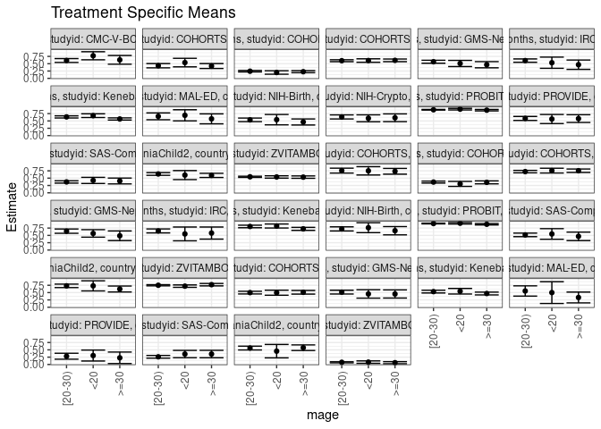

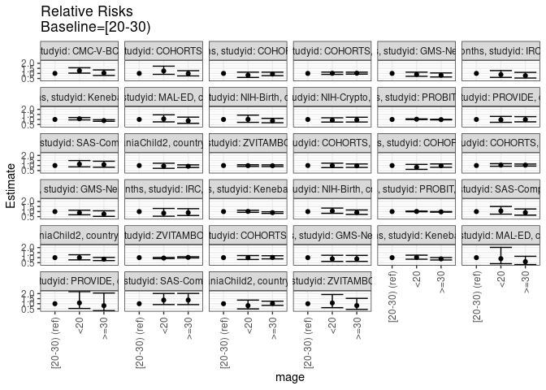

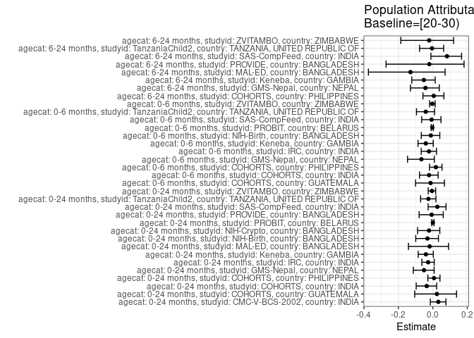

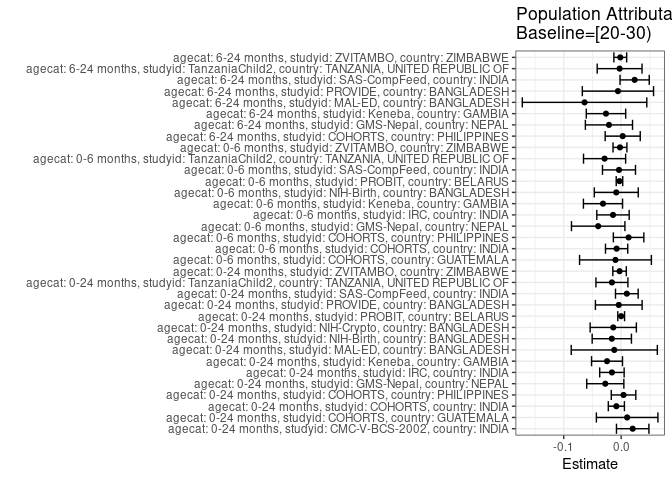

## Results Table

### Parameter: TSM

| agecat | studyid | country | intervention_level | baseline_level | estimate | ci_lower | ci_upper |
| --- | --- | --- | --- | --- | --- | --- | --- |
| 0-24 months | CMC-V-BCS-2002 | INDIA | [20-30) | NA | 0.6095618 | 0.5440036 | 0.6751199 |
| 0-24 months | CMC-V-BCS-2002 | INDIA | <20 | NA | 0.7714286 | 0.6337889 | 0.9090682 |
| 0-24 months | CMC-V-BCS-2002 | INDIA | >=30 | NA | 0.6315789 | 0.4824082 | 0.7807497 |
| 0-24 months | COHORTS | GUATEMALA | [20-30) | NA | 0.4316940 | 0.3586829 | 0.5047050 |
| 0-24 months | COHORTS | GUATEMALA | <20 | NA | 0.5384615 | 0.3923849 | 0.6845382 |
| 0-24 months | COHORTS | GUATEMALA | >=30 | NA | 0.4206897 | 0.3369595 | 0.5044198 |
| 0-24 months | COHORTS | INDIA | [20-30) | NA | 0.2439418 | 0.2196135 | 0.2682701 |
| 0-24 months | COHORTS | INDIA | <20 | NA | 0.2000000 | 0.1410052 | 0.2589948 |
| 0-24 months | COHORTS | INDIA | >=30 | NA | 0.2274436 | 0.1925299 | 0.2623573 |
| 0-24 months | COHORTS | PHILIPPINES | [20-30) | NA | 0.6027254 | 0.5692538 | 0.6361970 |
| 0-24 months | COHORTS | PHILIPPINES | <20 | NA | 0.6080000 | 0.5490467 | 0.6669533 |
| 0-24 months | COHORTS | PHILIPPINES | >=30 | NA | 0.6144330 | 0.5694107 | 0.6594552 |
| 0-24 months | GMS-Nepal | NEPAL | [20-30) | NA | 0.5673077 | 0.5166775 | 0.6179378 |
| 0-24 months | GMS-Nepal | NEPAL | <20 | NA | 0.5079365 | 0.4026576 | 0.6132154 |
| 0-24 months | GMS-Nepal | NEPAL | >=30 | NA | 0.4653465 | 0.3602822 | 0.5704109 |
| 0-24 months | IRC | INDIA | [20-30) | NA | 0.6059701 | 0.5489040 | 0.6630363 |
| 0-24 months | IRC | INDIA | <20 | NA | 0.5333333 | 0.3421602 | 0.7245064 |
| 0-24 months | IRC | INDIA | >=30 | NA | 0.4666667 | 0.3071858 | 0.6261475 |
| 0-24 months | Keneba | GAMBIA | [20-30) | NA | 0.6372549 | 0.6002795 | 0.6742303 |
| 0-24 months | Keneba | GAMBIA | <20 | NA | 0.6798246 | 0.6166059 | 0.7430432 |
| 0-24 months | Keneba | GAMBIA | >=30 | NA | 0.5670103 | 0.5305855 | 0.6034351 |
| 0-24 months | MAL-ED | BANGLADESH | [20-30) | NA | 0.6571429 | 0.5406898 | 0.7735959 |
| 0-24 months | MAL-ED | BANGLADESH | <20 | NA | 0.6923077 | 0.5029558 | 0.8816596 |
| 0-24 months | MAL-ED | BANGLADESH | >=30 | NA | 0.5714286 | 0.4018241 | 0.7410330 |
| 0-24 months | NIH-Birth | BANGLADESH | [20-30) | NA | 0.5365854 | 0.4751640 | 0.5980067 |
| 0-24 months | NIH-Birth | BANGLADESH | <20 | NA | 0.5428571 | 0.3658374 | 0.7198769 |
| 0-24 months | NIH-Birth | BANGLADESH | >=30 | NA | 0.4639175 | 0.3608362 | 0.5669988 |
| 0-24 months | NIH-Crypto | BANGLADESH | [20-30) | NA | 0.6363636 | 0.5675310 | 0.7051963 |
| 0-24 months | NIH-Crypto | BANGLADESH | <20 | NA | 0.5901639 | 0.4723983 | 0.7079295 |
| 0-24 months | NIH-Crypto | BANGLADESH | >=30 | NA | 0.6078431 | 0.4756675 | 0.7400188 |

[output cut: 72 more lines]

### Parameter: E(Y)

| agecat | studyid | country | intervention_level | baseline_level | estimate | ci_lower | ci_upper |
| --- | --- | --- | --- | --- | --- | --- | --- |
| 0-24 months | CMC-V-BCS-2002 | INDIA | NA | NA | 0.6296296 | 0.5734927 | 0.6857666 |
| 0-24 months | COHORTS | GUATEMALA | NA | NA | 0.4421053 | 0.3904403 | 0.4937702 |
| 0-24 months | COHORTS | INDIA | NA | NA | 0.2355670 | 0.2165976 | 0.2545364 |
| 0-24 months | COHORTS | PHILIPPINES | NA | NA | 0.6068680 | 0.5823645 | 0.6313715 |
| 0-24 months | GMS-Nepal | NEPAL | NA | NA | 0.5396579 | 0.4973524 | 0.5819633 |
| 0-24 months | IRC | INDIA | NA | NA | 0.5898734 | 0.5376978 | 0.6420491 |
| 0-24 months | Keneba | GAMBIA | NA | NA | 0.6126374 | 0.5884768 | 0.6367979 |
| 0-24 months | MAL-ED | BANGLADESH | NA | NA | 0.6451613 | 0.5593015 | 0.7310211 |
| 0-24 months | NIH-Birth | BANGLADESH | NA | NA | 0.5202864 | 0.4695109 | 0.5710618 |
| 0-24 months | NIH-Crypto | BANGLADESH | NA | NA | 0.6225806 | 0.5684562 | 0.6767051 |
| 0-24 months | PROBIT | BELARUS | NA | NA | 0.8806715 | 0.8711794 | 0.8901636 |
| 0-24 months | PROVIDE | BANGLADESH | NA | NA | 0.5811688 | 0.5245443 | 0.6377934 |
| 0-24 months | SAS-CompFeed | INDIA | NA | NA | 0.3808354 | 0.3457640 | 0.4159068 |
| 0-24 months | TanzaniaChild2 | TANZANIA, UNITED REPUBLIC OF | NA | NA | 0.6267606 | 0.5890263 | 0.6644948 |
| 0-24 months | ZVITAMBO | ZIMBABWE | NA | NA | 0.5434360 | 0.5270156 | 0.5598565 |
| 0-6 months | COHORTS | GUATEMALA | NA | NA | 0.7476636 | 0.6894668 | 0.8058603 |
| 0-6 months | COHORTS | INDIA | NA | NA | 0.3581505 | 0.3318331 | 0.3844678 |
| 0-6 months | COHORTS | PHILIPPINES | NA | NA | 0.7367021 | 0.7051294 | 0.7682749 |
| 0-6 months | GMS-Nepal | NEPAL | NA | NA | 0.6045627 | 0.5449300 | 0.6641955 |
| 0-6 months | IRC | INDIA | NA | NA | 0.6375000 | 0.5751450 | 0.6998550 |
| 0-6 months | Keneba | GAMBIA | NA | NA | 0.7728532 | 0.7426787 | 0.8030276 |
| 0-6 months | NIH-Birth | BANGLADESH | NA | NA | 0.7130045 | 0.6535890 | 0.7724200 |
| 0-6 months | PROBIT | BELARUS | NA | NA | 0.9008671 | 0.8918443 | 0.9098900 |
| 0-6 months | SAS-CompFeed | INDIA | NA | NA | 0.5131965 | 0.4596632 | 0.5667297 |
| 0-6 months | TanzaniaChild2 | TANZANIA, UNITED REPUBLIC OF | NA | NA | 0.7020649 | 0.6526590 | 0.7514708 |
| 0-6 months | ZVITAMBO | ZIMBABWE | NA | NA | 0.7485054 | 0.7315407 | 0.7654701 |
| 6-24 months | COHORTS | PHILIPPINES | NA | NA | 0.5026681 | 0.4688378 | 0.5364984 |
| 6-24 months | GMS-Nepal | NEPAL | NA | NA | 0.4947368 | 0.4401559 | 0.5493178 |
| 6-24 months | Keneba | GAMBIA | NA | NA | 0.5072860 | 0.4757518 | 0.5388202 |
| 6-24 months | MAL-ED | BANGLADESH | NA | NA | 0.4918033 | 0.3610932 | 0.6225134 |
| 6-24 months | PROVIDE | BANGLADESH | NA | NA | 0.2764228 | 0.1950773 | 0.3577682 |
| 6-24 months | SAS-CompFeed | INDIA | NA | NA | 0.2854123 | 0.2436284 | 0.3271961 |
| 6-24 months | TanzaniaChild2 | TANZANIA, UNITED REPUBLIC OF | NA | NA | 0.5579515 | 0.5056058 | 0.6102972 |
| 6-24 months | ZVITAMBO | ZIMBABWE | NA | NA | 0.0731261 | 0.0577817 | 0.0884705 |

### Parameter: RR

| agecat | studyid | country | intervention_level | baseline_level | estimate | ci_lower | ci_upper |
| --- | --- | --- | --- | --- | --- | --- | --- |
| 0-24 months | CMC-V-BCS-2002 | INDIA | [20-30) | [20-30) | 1.0000000 | 1.0000000 | 1.0000000 |
| 0-24 months | CMC-V-BCS-2002 | INDIA | <20 | [20-30) | 1.2655462 | 1.0275196 | 1.5587122 |
| 0-24 months | CMC-V-BCS-2002 | INDIA | >=30 | [20-30) | 1.0361197 | 0.7992780 | 1.3431423 |
| 0-24 months | COHORTS | GUATEMALA | [20-30) | [20-30) | 1.0000000 | 1.0000000 | 1.0000000 |
| 0-24 months | COHORTS | GUATEMALA | <20 | [20-30) | 1.2473223 | 0.9060073 | 1.7172190 |
| 0-24 months | COHORTS | GUATEMALA | >=30 | [20-30) | 0.9745089 | 0.7504518 | 1.2654613 |
| 0-24 months | COHORTS | INDIA | [20-30) | [20-30) | 1.0000000 | 1.0000000 | 1.0000000 |
| 0-24 months | COHORTS | INDIA | <20 | [20-30) | 0.8198675 | 0.6005015 | 1.1193691 |
| 0-24 months | COHORTS | INDIA | >=30 | [20-30) | 0.9323682 | 0.7764009 | 1.1196669 |
| 0-24 months | COHORTS | PHILIPPINES | [20-30) | [20-30) | 1.0000000 | 1.0000000 | 1.0000000 |
| 0-24 months | COHORTS | PHILIPPINES | <20 | [20-30) | 1.0087513 | 0.9020876 | 1.1280271 |
| 0-24 months | COHORTS | PHILIPPINES | >=30 | [20-30) | 1.0194245 | 0.9298619 | 1.1176135 |
| 0-24 months | GMS-Nepal | NEPAL | [20-30) | [20-30) | 1.0000000 | 1.0000000 | 1.0000000 |
| 0-24 months | GMS-Nepal | NEPAL | <20 | [20-30) | 0.8953457 | 0.7144412 | 1.1220573 |
| 0-24 months | GMS-Nepal | NEPAL | >=30 | [20-30) | 0.8202719 | 0.6434234 | 1.0457282 |
| 0-24 months | IRC | INDIA | [20-30) | [20-30) | 1.0000000 | 1.0000000 | 1.0000000 |
| 0-24 months | IRC | INDIA | <20 | [20-30) | 0.8801314 | 0.6075574 | 1.2749927 |
| 0-24 months | IRC | INDIA | >=30 | [20-30) | 0.7701149 | 0.5402651 | 1.0977519 |
| 0-24 months | Keneba | GAMBIA | [20-30) | [20-30) | 1.0000000 | 1.0000000 | 1.0000000 |
| 0-24 months | Keneba | GAMBIA | <20 | [20-30) | 1.0668016 | 0.9560639 | 1.1903657 |
| 0-24 months | Keneba | GAMBIA | >=30 | [20-30) | 0.8897700 | 0.8159914 | 0.9702194 |
| 0-24 months | MAL-ED | BANGLADESH | [20-30) | [20-30) | 1.0000000 | 1.0000000 | 1.0000000 |
| 0-24 months | MAL-ED | BANGLADESH | <20 | [20-30) | 1.0535117 | 0.7605022 | 1.4594131 |
| 0-24 months | MAL-ED | BANGLADESH | >=30 | [20-30) | 0.8695652 | 0.6151686 | 1.2291649 |
| 0-24 months | NIH-Birth | BANGLADESH | [20-30) | [20-30) | 1.0000000 | 1.0000000 | 1.0000000 |
| 0-24 months | NIH-Birth | BANGLADESH | <20 | [20-30) | 1.0116883 | 0.7161022 | 1.4292838 |
| 0-24 months | NIH-Birth | BANGLADESH | >=30 | [20-30) | 0.8645736 | 0.6733556 | 1.1100932 |
| 0-24 months | NIH-Crypto | BANGLADESH | [20-30) | [20-30) | 1.0000000 | 1.0000000 | 1.0000000 |
| 0-24 months | NIH-Crypto | BANGLADESH | <20 | [20-30) | 0.9274005 | 0.7388195 | 1.1641161 |
| 0-24 months | NIH-Crypto | BANGLADESH | >=30 | [20-30) | 0.9551821 | 0.7490222 | 1.2180851 |

[output cut: 72 more lines]

### Parameter: PAR

| agecat | studyid | country | intervention_level | baseline_level | estimate | ci_lower | ci_upper |
| --- | --- | --- | --- | --- | --- | --- | --- |
| 0-24 months | CMC-V-BCS-2002 | INDIA | [20-30) | NA | 0.0200679 | -0.0081753 | 0.0483111 |
| 0-24 months | COHORTS | GUATEMALA | [20-30) | NA | 0.0104113 | -0.0431759 | 0.0639984 |
| 0-24 months | COHORTS | INDIA | [20-30) | NA | -0.0083748 | -0.0223883 | 0.0056387 |
| 0-24 months | COHORTS | PHILIPPINES | [20-30) | NA | 0.0041426 | -0.0172129 | 0.0254981 |
| 0-24 months | GMS-Nepal | NEPAL | [20-30) | NA | -0.0276498 | -0.0599772 | 0.0046776 |
| 0-24 months | IRC | INDIA | [20-30) | NA | -0.0160967 | -0.0373720 | 0.0051786 |
| 0-24 months | Keneba | GAMBIA | [20-30) | NA | -0.0246175 | -0.0515649 | 0.0023298 |
| 0-24 months | MAL-ED | BANGLADESH | [20-30) | NA | -0.0119816 | -0.0869654 | 0.0630023 |
| 0-24 months | NIH-Birth | BANGLADESH | [20-30) | NA | -0.0162990 | -0.0504996 | 0.0179016 |
| 0-24 months | NIH-Crypto | BANGLADESH | [20-30) | NA | -0.0137830 | -0.0540277 | 0.0264618 |
| 0-24 months | PROBIT | BELARUS | [20-30) | NA | 0.0000233 | -0.0058532 | 0.0058999 |
| 0-24 months | PROVIDE | BANGLADESH | [20-30) | NA | -0.0041970 | -0.0448502 | 0.0364562 |
| 0-24 months | SAS-CompFeed | INDIA | [20-30) | NA | 0.0098676 | -0.0098676 | 0.0296029 |
| 0-24 months | TanzaniaChild2 | TANZANIA, UNITED REPUBLIC OF | [20-30) | NA | -0.0160966 | -0.0439482 | 0.0117550 |
| 0-24 months | ZVITAMBO | ZIMBABWE | [20-30) | NA | -0.0027789 | -0.0145087 | 0.0089508 |
| 0-6 months | COHORTS | GUATEMALA | [20-30) | NA | -0.0099122 | -0.0724377 | 0.0526132 |
| 0-6 months | COHORTS | INDIA | [20-30) | NA | -0.0079101 | -0.0272917 | 0.0114714 |
| 0-6 months | COHORTS | PHILIPPINES | [20-30) | NA | 0.0129578 | -0.0135854 | 0.0395011 |
| 0-6 months | GMS-Nepal | NEPAL | [20-30) | NA | -0.0400156 | -0.0865473 | 0.0065162 |
| 0-6 months | IRC | INDIA | [20-30) | NA | -0.0142413 | -0.0424320 | 0.0139495 |
| 0-6 months | Keneba | GAMBIA | [20-30) | NA | -0.0316340 | -0.0657240 | 0.0024560 |
| 0-6 months | NIH-Birth | BANGLADESH | [20-30) | NA | -0.0085145 | -0.0467921 | 0.0297631 |
| 0-6 months | PROBIT | BELARUS | [20-30) | NA | -0.0029418 | -0.0086174 | 0.0027338 |
| 0-6 months | SAS-CompFeed | INDIA | [20-30) | NA | -0.0037847 | -0.0325238 | 0.0249545 |
| 0-6 months | TanzaniaChild2 | TANZANIA, UNITED REPUBLIC OF | [20-30) | NA | -0.0288768 | -0.0655418 | 0.0077881 |
| 0-6 months | ZVITAMBO | ZIMBABWE | [20-30) | NA | -0.0020941 | -0.0141695 | 0.0099812 |
| 6-24 months | COHORTS | PHILIPPINES | [20-30) | NA | 0.0026681 | -0.0278732 | 0.0332093 |
| 6-24 months | GMS-Nepal | NEPAL | [20-30) | NA | -0.0212632 | -0.0623204 | 0.0197941 |
| 6-24 months | Keneba | GAMBIA | [20-30) | NA | -0.0264442 | -0.0607499 | 0.0078615 |
| 6-24 months | MAL-ED | BANGLADESH | [20-30) | NA | -0.0637523 | -0.1721469 | 0.0446423 |
| 6-24 months | PROVIDE | BANGLADESH | [20-30) | NA | -0.0056285 | -0.0676577 | 0.0564006 |
| 6-24 months | SAS-CompFeed | INDIA | [20-30) | NA | 0.0234404 | -0.0020153 | 0.0488962 |
| 6-24 months | TanzaniaChild2 | TANZANIA, UNITED REPUBLIC OF | [20-30) | NA | -0.0027180 | -0.0417530 | 0.0363171 |
| 6-24 months | ZVITAMBO | ZIMBABWE | [20-30) | NA | -0.0015627 | -0.0126962 | 0.0095709 |

### Parameter: PAF

| agecat | studyid | country | intervention_level | baseline_level | estimate | ci_lower | ci_upper |
| --- | --- | --- | --- | --- | --- | --- | --- |
| 0-24 months | CMC-V-BCS-2002 | INDIA | [20-30) | NA | 0.0318725 | -0.0144597 | 0.0760887 |
| 0-24 months | COHORTS | GUATEMALA | [20-30) | NA | 0.0235493 | -0.1054210 | 0.1374725 |
| 0-24 months | COHORTS | INDIA | [20-30) | NA | -0.0355518 | -0.0966517 | 0.0221439 |
| 0-24 months | COHORTS | PHILIPPINES | [20-30) | NA | 0.0068262 | -0.0290128 | 0.0414170 |
| 0-24 months | GMS-Nepal | NEPAL | [20-30) | NA | -0.0512359 | -0.1134411 | 0.0074942 |
| 0-24 months | IRC | INDIA | [20-30) | NA | -0.0272885 | -0.0639884 | 0.0081456 |
| 0-24 months | Keneba | GAMBIA | [20-30) | NA | -0.0401829 | -0.0850689 | 0.0028463 |
| 0-24 months | MAL-ED | BANGLADESH | [20-30) | NA | -0.0185714 | -0.1415944 | 0.0911941 |
| 0-24 months | NIH-Birth | BANGLADESH | [20-30) | NA | -0.0313269 | -0.0992537 | 0.0324024 |
| 0-24 months | NIH-Crypto | BANGLADESH | [20-30) | NA | -0.0221385 | -0.0888097 | 0.0404503 |
| 0-24 months | PROBIT | BELARUS | [20-30) | NA | 0.0000265 | -0.0066686 | 0.0066770 |
| 0-24 months | PROVIDE | BANGLADESH | [20-30) | NA | -0.0072217 | -0.0796894 | 0.0603821 |
| 0-24 months | SAS-CompFeed | INDIA | [20-30) | NA | 0.0259105 | -0.0273423 | 0.0764030 |
| 0-24 months | TanzaniaChild2 | TANZANIA, UNITED REPUBLIC OF | [20-30) | NA | -0.0256822 | -0.0711606 | 0.0178654 |
| 0-24 months | ZVITAMBO | ZIMBABWE | [20-30) | NA | -0.0051137 | -0.0269336 | 0.0162427 |
| 0-6 months | COHORTS | GUATEMALA | [20-30) | NA | -0.0132576 | -0.1004856 | 0.0670564 |
| 0-6 months | COHORTS | INDIA | [20-30) | NA | -0.0220861 | -0.0776635 | 0.0306251 |
| 0-6 months | COHORTS | PHILIPPINES | [20-30) | NA | 0.0175890 | -0.0191519 | 0.0530053 |
| 0-6 months | GMS-Nepal | NEPAL | [20-30) | NA | -0.0661893 | -0.1468000 | 0.0087552 |
| 0-6 months | IRC | INDIA | [20-30) | NA | -0.0223393 | -0.0676463 | 0.0210451 |
| 0-6 months | Keneba | GAMBIA | [20-30) | NA | -0.0409314 | -0.0861857 | 0.0024374 |
| 0-6 months | NIH-Birth | BANGLADESH | [20-30) | NA | -0.0119417 | -0.0670961 | 0.0403619 |
| 0-6 months | PROBIT | BELARUS | [20-30) | NA | -0.0032655 | -0.0095871 | 0.0030165 |
| 0-6 months | SAS-CompFeed | INDIA | [20-30) | NA | -0.0073747 | -0.0649690 | 0.0471049 |
| 0-6 months | TanzaniaChild2 | TANZANIA, UNITED REPUBLIC OF | [20-30) | NA | -0.0411313 | -0.0950270 | 0.0101118 |
| 0-6 months | ZVITAMBO | ZIMBABWE | [20-30) | NA | -0.0027978 | -0.0190615 | 0.0132064 |
| 6-24 months | COHORTS | PHILIPPINES | [20-30) | NA | 0.0053079 | -0.0573475 | 0.0642505 |
| 6-24 months | GMS-Nepal | NEPAL | [20-30) | NA | -0.0429787 | -0.1300677 | 0.0373987 |
| 6-24 months | Keneba | GAMBIA | [20-30) | NA | -0.0521288 | -0.1220642 | 0.0134478 |
| 6-24 months | MAL-ED | BANGLADESH | [20-30) | NA | -0.1296296 | -0.3739720 | 0.0712597 |
| 6-24 months | PROVIDE | BANGLADESH | [20-30) | NA | -0.0203620 | -0.2715476 | 0.1812036 |
| 6-24 months | SAS-CompFeed | INDIA | [20-30) | NA | 0.0821283 | -0.0111679 | 0.1668165 |
| 6-24 months | TanzaniaChild2 | TANZANIA, UNITED REPUBLIC OF | [20-30) | NA | -0.0048713 | -0.0773326 | 0.0627161 |
| 6-24 months | ZVITAMBO | ZIMBABWE | [20-30) | NA | -0.0213693 | -0.1858258 | 0.1202795 |